# Clean version of the Linear Mixed Model analysis

Théo Guillerminet

11 Février 2022

```r
library(magrittr)
library(tidyr)
library(dplyr)
library(stringr)
library(ggplot2)
library(lme4)
library(lmerTest)
library(pbkrtest)
library(broom.mixed)
library(kableExtra)
```

# 1 Initialisation and data import

```r
source("scripts/init.R")
source("scripts/import_data.R")
source("scripts/data_phenot_get_parameters_std.R")
source("scripts/data_phenot_outliers_exclusion_std.R")

glimpse(data_phenot_parms_clean)
```

```
## Rows: 1,981
## Columns: 6
## $ robot_id    <chr> "R20-20210930-001", "R20-20210930-001", "R20-20210930-001"~
## $ strain_name <chr> "LB-PD7-T1-1", "LB-PD7-T1-1", "LB-PD7-T1-1", "LB-PD7-T1-1"~
## $ bloc        <fct> 3, 3, 3, 3, 3, 3, 3, 3, 3, 3, 3, 3, 3, 3, 3, 3, 3, 3, 3, 3~
## $ bloc_month  <fct> 1, 1, 1, 1, 1, 1, 1, 1, 1, 1, 1, 1, 1, 1, 1, 1, 1, 1, 1, 1~
## $ parameter   <chr> "cell_t0", "co2max", "death_prct", "lag", "pop_size", "tvm~
## $ value       <dbl> 9.810000e+05, 2.223684e+01, 1.330000e+01, 9.868000e+00, 6.~
```

# 2 Only for LB

## 2.1 Data visualisation & Hypotheses

```r
data_phenot_parms_clean_LB <- data_phenot_parms_clean %>%
  filter(parameter != "cell_t0",
         grepl("^LB", strain_name),
         !grepl("-T5-", strain_name)) %>%
  mutate(flour_id = strains$flour_id[match(strain_name, strains$strain_name)],
         baker_id = strains$baker_id[match(strain_name, strains$strain_name)],
         flour_type = flours$mill_type[match(flour_id, flours$flour_id)],
         backslopping = strains$backslopping[match(strain_name,
                                                   strains$strain_name)],
         bs_time = backsloppings$bs_time[match(interaction(backslopping, baker_id),
                                               interaction(backsloppings$backslopping,
                                                           backsloppings$baker_id))],
         cell_t0 = data_cyto$cell_t0[match(robot_id, data_cyto$robot_id)]) %>%
  filter(!if_any(everything(), ~ is.na(.x)))
```

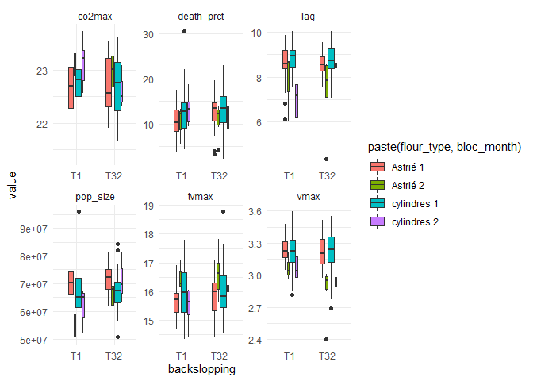

```r
ggplot(data_phenot_parms_clean_LB) +
  aes(x = backslopping, y = value, fill = paste(flour_type, bloc_month)) +
  geom_boxplot(varwidth = T) +
  facet_wrap(~ parameter, scales = "free") +
  theme_minimal()
```

## 2.2 Formulation du modèle

Variable continue en effet aléatoire > **NON** (https://stats.stackexchange.com/questions/105698/how-do-i-enter-a-continuous-variable-as-a-random-effect-in-a-linear-mixed-effect)

La variable $cell_{t_0}$ n’a pas sens comme effet aléatoire.

The complete model is defined as follow :

[output not shown]

## 2.3 Test des effets aléatoires

### 2.3.1 Biblio sur le test des effets aléatoire

https://stats.stackexchange.com/questions/56150/how-can-i-test-whether-a-random-effect-is-significant

Possibilité : LRT, AIC ou boostrap paramétrique pour le LRT

**Or**, Ce n’est pas techniquement pertinent de faire un test LRT classique entre deux modèles mixtes avec la fonction `anova(m1, m2, test = "LRT")` :

*“Ce problème se pose fréquemment dans les modèles à effets aléatoires ou mixtes, où un ou plusieurs paramètres du modèle représentent la variance d’un terme d’effet aléatoire. La variance ne peut pas être négative, donc si l’on compare un modèle avec et sans un terme d’effet aléatoire particulier, le modèle sans le terme suppose que la valeur du paramètre de variance est 0. Mais 0 est à la limite inférieure des valeurs possibles (*lower boundary of the possible values*) que le paramètre peut prendre, pourtant le LRT par défaut suppose que des valeurs négatives sont possibles pour le paramètre. D’où le commentaire sur la fiabilité de l’utilisation de la distribution du chi-deux avec d degrés de liberté pour la statistique de test dans de tels cas.*

*Comparez cette situation avec un paramètre pour un terme à effet fixe dans un modèle linéaire (mixte). Ce paramètre est la moyenne estimée d’une variable aléatoire gaussienne et, théoriquement, il peut prendre n’importe quelle valeur et donc, dans un LRT où nous pourrions comparer un modèle et un modèle sans ce terme à effet fixe (et donc en fixant $\hat\beta=0$ dans le modèle sans le terme), le paramètre pour le modèle plus simple ($\hat\beta=0$) n’est pas à la limite de l’ensemble des valeurs autorisées.”*

(https://stats.stackexchange.com/questions/97682/likelihood-ratio-test-and-boundary-parameters)

**Or** là, je n’arrive pas à utiliser la fonction `pbkrtest::PBmodcomp(m1, m2)` pour comparer des modèles linéaires mixtes et des modèles linéaires simple à cause des différentes classes d’objets (*i.e.* `lm` et `lmer`).

Donc je fais un LRT classique.

Douglas Bates, co-développeur du package `lme4` utilise le LRT de cette manière dans son livre (Bates 2010) mais émet clairement cette mise en garde concernant les valeurs de paramètres testés à la limite de l’ensemble des valeurs possibles.

### 2.3.2 Model versions

```r
modv_LB_ran <- list(value ~ backslopping + backslopping:flour_type
                    + (1|strain_name) + (1|bloc_month),
                    value ~ backslopping + backslopping:flour_type
                    + (1|strain_name),
                    value ~ backslopping + backslopping:flour_type
                    + (1|bloc_month),
                    value ~ backslopping + backslopping:flour_type)
```

### 2.3.3 Model fitting

```r
fits <- data_phenot_parms_clean_LB %>%
  group_by(parameter) %>%
  nest() %>%
  mutate(n_model = length(modv_LB_ran)) %>%
  uncount(n_model) %>%
  ungroup() %>%
  mutate(model = rep(as.character(modv_LB_ran), length(unique(parameter))),
         id = 1:nrow(.),
         n_terms = str_count(" \\+ ", string = model) + 1) %>%
  rowwise() %>%

  #Uses 'lmer' if the model is mixed or 'lm' if the model is only made of fixed effects
  mutate(fit = ifelse(grepl("\\)$", model) == TRUE,
                      yes = list(lmer(as.formula(model), data, REML = F)),
                      no = list(lm(as.formula(model), data, contrasts = list(variable = "contr.sum"))))) %>%
  ungroup() %>%
  group_by(parameter) %>%

  # Indicates the id(s) of the model(s) in which the model of the given line is nested in
  mutate(nested_in = map2(model, id, ~ id[which(grepl(.x, model, fixed = T) & .y != id & abs(n_terms[match(.y, id)] - n_terms) == 1)])) %>%
  ungroup()
```

### 2.3.4 Likelihood Ratio Test (LRT)

Pour chaque paramètre (6), LRT entre chaque paire de modèle nichés (3) à 1 paramètre près.

```r
ran_test_LB <- fits %>%
  unnest(nested_in, keep_empty = T) %>%
  mutate(fit_long = fit[match(nested_in, id)],
         model_long = model[match(nested_in, id)]) %>%
  filter(!is.na(model_long)) %>%
  rowwise() %>%
  mutate(test = list(list(fit_long = model_long,
                          fit = model,
                          diff = as.character(sub(model, "", model_long, fixed = T)),
                          lrt = anova(fit_long, fit)))) %>%
  ungroup() %>%
  mutate(pval = map_dbl(test, ~ .$lrt$`Pr(>Chisq)`[2])) %>%
  filter(pval < 0.1)
```

Tests pour lesquels la *p.value* est inférieure à 0.1 :

```r
for(i in 1:nrow(ran_test_LB)) {

  cat("Parameter :", ran_test_LB$parameter[[i]], "\n")
  cat("Long :", ran_test_LB$model_long[[i]], "\n")
  cat("Short :", ran_test_LB$model[[i]], "\n")
  cat("Diff :", ran_test_LB$test[[i]]$diff, "\n\n")
  cat(grep("(npar)|(^fit   )|(^fit_long   )", capture.output(ran_test_LB$test[[i]]$lrt), value = TRUE), sep = "\n")
  cat("\n-----\n")

}
```

```
## Parameter : lag
## Long : value ~ backslopping + backslopping:flour_type + (1 | strain_name) + (1 | bloc_month)
## Short : value ~ backslopping + backslopping:flour_type + (1 | strain_name)
## Diff :  + (1 | bloc_month)
##
##          npar    AIC    BIC  logLik deviance  Chisq Df Pr(>Chisq)
## fit         6 387.57 405.51 -187.79   375.57
## fit_long    7 368.58 389.52 -177.29   354.58 20.988  1  4.623e-06 ***
##
## -----
## Parameter : lag
## Long : value ~ backslopping + backslopping:flour_type + (1 | bloc_month)
## Short : value ~ backslopping + backslopping:flour_type
## Diff :  + (1 | bloc_month)
##
##          npar    AIC    BIC  logLik deviance  Chisq Df Pr(>Chisq)
## fit         5 385.57 400.52 -187.79   375.57
## fit_long    6 366.58 384.53 -177.29   354.58 20.988  1  4.623e-06 ***
##
## -----
## Parameter : pop_size
## Long : value ~ backslopping + backslopping:flour_type + (1 | strain_name)
## Short : value ~ backslopping + backslopping:flour_type
## Diff :  + (1 | strain_name)
##
##          npar    AIC    BIC  logLik deviance  Chisq Df Pr(>Chisq)
## fit         5 5081.9 5096.8 -2535.9   5071.9
## fit_long    6 5080.8 5098.7 -2534.4   5068.8 3.1003  1    0.07828 .
##
## -----
## Parameter : vmax
## Long : value ~ backslopping + backslopping:flour_type + (1 | strain_name) + (1 | bloc_month)
## Short : value ~ backslopping + backslopping:flour_type + (1 | strain_name)
## Diff :  + (1 | bloc_month)
##
##          npar     AIC     BIC logLik deviance  Chisq Df Pr(>Chisq)
## fit         6 -70.511 -52.568 41.255  -82.511
## fit_long    7 -92.473 -71.540 53.237 -106.473 23.963  1  9.823e-07 ***
##
## -----
## Parameter : vmax
## Long : value ~ backslopping + backslopping:flour_type + (1 | bloc_month)
## Short : value ~ backslopping + backslopping:flour_type
## Diff :  + (1 | bloc_month)
##
##          npar     AIC     BIC logLik deviance  Chisq Df Pr(>Chisq)
## fit         5 -72.187 -57.234 41.093  -82.187
## fit_long    6 -93.365 -75.423 52.683 -105.365 23.178  1  1.476e-06 ***
##
## -----
```

Synthèse :

```r
ran_test_LB %>%
  mutate(diff = map_chr(test, ~ .$diff),
         pval = round(pval, 4)) %>%
  select(parameter, diff, pval)
```

```
## # A tibble: 5 x 3
##   parameter diff                     pval
##   <chr>     <chr>                   <dbl>
## 1 lag       " + (1 | bloc_month)"  0
## 2 lag       " + (1 | bloc_month)"  0
## 3 pop_size  " + (1 | strain_name)" 0.0783
## 4 vmax      " + (1 | bloc_month)"  0
## 5 vmax      " + (1 | bloc_month)"  0
```

Donc pour les variables $lag$, $v_{max}$, seul l’effet aléatoire $bloc_{month}$ doit être inclus au modèle. Pour les autres paramètres, aucun effet aléatoire n’est significatif.

## 2.4 Test des effets fixes

Donc, pour les variables $lag$, $v_{max}$. Le modèle complet ajusté est :

```
## value ~ backslopping + backslopping:flour_type + (1 | bloc_month)
```

Et pour les variables $CO_2{max}$, $death_\%$, $pop_{size}$ et $t_{V_{max}}$ le modèle complet est le suivant :

```
## value ~ backslopping + backslopping:flour_type
```

### 2.4.1 Model fitting

```r
fits <- data_phenot_parms_clean_LB %>%
  group_by(parameter) %>%
  nest() %>%
  ungroup() %>%
  mutate(model = case_when(parameter %in% c("lag", "vmax") ~ list(mod_vers(value ~ backslopping + backslopping:flour_type + (1 | bloc_month), 3)),
                           parameter %in% c("co2max", "tvmax","death_prct","pop_size") ~ list(mod_vers(value ~ backslopping + backslopping:flour_type)))) %>%
  unnest(model) %>%
  mutate(id = 1:nrow(.),
         n_terms = str_count(" \\+ ", string = model) + 1) %>%
  rowwise() %>%

  #Uses 'lmer' if the model is mixed (i.e. ending with a closing parenthese) or 'lm' if the model is only made of fixed effects
  mutate(fit = ifelse(grepl("\\)$", model) == TRUE,
                      yes = list(lmer(as.formula(model), data, REML = F)),
                      no = list(lm(as.formula(model), data)))) %>%
  ungroup()
```

### 2.4.2 Tableau d’ANOVA

```r
anovas <- fits %>%
  group_by(parameter) %>%
  filter(n_terms == max(n_terms)) %>%
  ungroup() %>%
  rowwise() %>%
  mutate(anova = list(anova(fit)))

for(i in 1:nrow(anovas)) {

  cat("Parameter :", anovas$parameter[[i]], "\n")
  cat("Model :", anovas$model[[i]], "\n")
  cat(capture.output(anovas$anova[[i]]), sep = "\n")
  cat("\n-----\n")

}
```

```
## Parameter : co2max
## Model : value ~ backslopping + backslopping:flour_type
## Analysis of Variance Table
##
## Response: value
##                          Df Sum Sq  Mean Sq F value Pr(>F)
## backslopping              1  0.027 0.026633  0.1046 0.7469
## backslopping:flour_type   2  0.405 0.202338  0.7944 0.4538
## Residuals               143 36.421 0.254695
##
## -----
## Parameter : death_prct
## Model : value ~ backslopping + backslopping:flour_type
## Analysis of Variance Table
##
## Response: value
##                          Df  Sum Sq Mean Sq F value Pr(>F)
## backslopping              1   36.87  36.871  1.9057 0.1696
## backslopping:flour_type   2   82.11  41.055  2.1220 0.1235
## Residuals               143 2766.68  19.347
##
## -----
## Parameter : lag
## Model : value ~ backslopping + backslopping:flour_type + (1 | bloc_month)
## Type III Analysis of Variance Table with Satterthwaite's method
##                          Sum Sq Mean Sq NumDF  DenDF F value Pr(>F)
## backslopping            0.07971 0.07971     1 145.07  0.1275 0.7216
## backslopping:flour_type 1.59973 0.79986     2 145.15  1.2791 0.2814
##
## -----
## Parameter : pop_size
## Model : value ~ backslopping + backslopping:flour_type
## Analysis of Variance Table
##
## Response: value
##                          Df     Sum Sq    Mean Sq F value Pr(>F)
## backslopping              1 5.1922e+13 5.1922e+13  0.8945 0.3459
## backslopping:flour_type   2 2.4763e+14 1.2381e+14  2.1330 0.1222
## Residuals               143 8.3006e+15 5.8046e+13
##
## -----
## Parameter : tvmax
## Model : value ~ backslopping + backslopping:flour_type
## Analysis of Variance Table
##
## Response: value
##                          Df Sum Sq Mean Sq F value  Pr(>F)
## backslopping              1  2.017 2.01728  3.5934 0.06003 .
## backslopping:flour_type   2  0.156 0.07776  0.1385 0.87077
## Residuals               143 80.278 0.56139
## ---
## Signif. codes:  0 '***' 0.001 '**' 0.01 '*' 0.05 '.' 0.1 ' ' 1
##
## -----
## Parameter : vmax
## Model : value ~ backslopping + backslopping:flour_type + (1 | bloc_month)
## Type III Analysis of Variance Table with Satterthwaite's method
##                           Sum Sq  Mean Sq NumDF  DenDF F value Pr(>F)
## backslopping            0.072248 0.072248     1 145.06  2.6430 0.1062
## backslopping:flour_type 0.026704 0.013352     2 145.14  0.4884 0.6146
##
## -----
```

### 2.4.3 Avec l’AIC

Comme dans : *Barnagaud, J.-Y., Crochet, P.A., Magnani, Y., Bernard Laurent, A., Menoni, E., Novoa, C., Gimenez, O., 2011. Short-term response to the North Atlantic Oscillation but no long-term effects of climate change on the reproductive success of an alpine bird. J Ornithol 152, 631–641. https://doi.org/10.1007/s10336-010-0623-8*

```r
fits %>%
  mutate(summary = map(fit, glance)) %>%
  unnest(summary) %>%
  select(-data, -fit) %>%
  group_by(parameter) %>%
  mutate(deltaAIC = AIC - min(AIC)) %>%
  select(id, parameter, model, logLik, AIC, deltaAIC, sigma, df.residual, n_terms) %>%
  mutate_if(is.numeric, ~ round(.x, 1)) %>%
  mutate(model = sub("^value ","", model),
         model = ifelse(deltaAIC < 2, str_replace_all(model, "^", "**"), model),
         model = ifelse(deltaAIC < 2, str_replace_all(model, "$", "**"), model)) %>%
  arrange(parameter, AIC, n_terms) %>%  kbl(format = "html", align = "c", escape = F) %>%
  kable_paper("striped", full_width = F) %>%
  row_spec(0, angle = 0) %>%
  scroll_box(width = "100%", height = "700px")
```

| id | parameter | model | logLik | AIC | deltaAIC | sigma | df.residual | n_terms |
| --- | --- | --- | --- | --- | --- | --- | --- | --- |
| 4 | co2max | **~ 1** | -106.9 | 217.8 | 0.0 | 0.5 | 146 | 1 |
| 1 | co2max | **~ backslopping** | -106.8 | 219.7 | 1.9 | 0.5 | 145 | 1 |
| 2 | co2max | ~ backslopping:flour_type | -106.0 | 222.1 | 4.3 | 0.5 | 143 | 1 |
| 3 | co2max | ~ backslopping + backslopping:flour_type | -106.0 | 222.1 | 4.3 | 0.5 | 143 | 2 |
| 6 | death_prct | **~ backslopping:flour_type** | -424.3 | 858.6 | 0.0 | 4.4 | 143 | 1 |
| 7 | death_prct | **~ backslopping + backslopping:flour_type** | -424.3 | 858.6 | 0.0 | 4.4 | 143 | 2 |
| 8 | death_prct | **~ 1** | -427.4 | 858.8 | 0.2 | 4.4 | 146 | 1 |
| 5 | death_prct | **~ backslopping** | -426.5 | 858.9 | 0.3 | 4.4 | 145 | 1 |
| 12 | lag | **~ 1 + (1 \| bloc_month)** | -178.6 | 363.2 | 0.0 | 0.8 | 144 | 2 |
| 9 | lag | **~ backslopping + (1 \| bloc_month)** | -178.6 | 365.1 | 1.9 | 0.8 | 143 | 2 |
| 10 | lag | ~ backslopping:flour_type + (1 \| bloc_month) | -177.3 | 366.6 | 3.3 | 0.8 | 141 | 2 |
| 11 | lag | ~ backslopping + backslopping:flour_type + (1 \| bloc_month) | -177.3 | 366.6 | 3.3 | 0.8 | 141 | 3 |
| 16 | pop_size | **~ 1** | -2538.5 | 5081.1 | 0.0 | 7674987.8 | 146 | 1 |
| 14 | pop_size | **~ backslopping:flour_type** | -2535.9 | 5081.9 | 0.8 | 7618823.5 | 143 | 1 |
| 15 | pop_size | **~ backslopping + backslopping:flour_type** | -2535.9 | 5081.9 | 0.8 | 7618823.5 | 143 | 2 |
| 13 | pop_size | **~ backslopping** | -2538.1 | 5082.2 | 1.1 | 7678124.8 | 145 | 1 |
| 17 | tvmax | **~ backslopping** | -164.3 | 334.5 | 0.0 | 0.7 | 145 | 1 |
| 20 | tvmax | **~ 1** | -166.1 | 336.2 | 1.6 | 0.8 | 146 | 1 |
| 18 | tvmax | ~ backslopping:flour_type | -164.1 | 338.2 | 3.7 | 0.7 | 143 | 1 |
| 19 | tvmax | ~ backslopping + backslopping:flour_type | -164.1 | 338.2 | 3.7 | 0.7 | 143 | 2 |
| 24 | vmax | **~ 1 + (1 \| bloc_month)** | 51.3 | -96.6 | 0.0 | 0.2 | 144 | 2 |
| 21 | vmax | **~ backslopping + (1 \| bloc_month)** | 52.2 | -96.4 | 0.2 | 0.2 | 143 | 2 |
| 22 | vmax | ~ backslopping:flour_type + (1 \| bloc_month) | 52.7 | -93.4 | 3.2 | 0.2 | 141 | 2 |
| 23 | vmax | ~ backslopping + backslopping:flour_type + (1 \| bloc_month) | 52.7 | -93.4 | 3.2 | 0.2 | 141 | 3 |

# 3 For LB and MB

## 3.1 Data visualisation & Hypotheses

We include only the data for strains isolated from the `LB` and `MB` baker and from backsloppings `T1` and `T32`, but not `T5` for which there are three strains :

```r
table(strains$baker_id, strains$backslopping)
```

```
##
##       T1 T5 T32
##   AM   3 11   0
##   LB  20  3  24
##   MB   7  0  21
##   PDC  1  0   1
```

```r
data_phenot_parms_clean_LBMB <- data_phenot_parms_clean %>%
  filter(parameter != "cell_t0",
         grepl("(^LB)|(^MB)", strain_name),
         !grepl("-T5-", strain_name)) %>%
  mutate(flour_id = strains$flour_id[match(strain_name, strains$strain_name)],
         baker_id = strains$baker_id[match(strain_name, strains$strain_name)],
         flour_type = flours$mill_type[match(flour_id, flours$flour_id)],
         backslopping = strains$backslopping[match(strain_name,
                                                   strains$strain_name)],
         bs_time = backsloppings$bs_time[match(interaction(backslopping, baker_id),
                                               interaction(backsloppings$backslopping,
                                                           backsloppings$baker_id))],
         cell_t0 = data_cyto$cell_t0[match(robot_id, data_cyto$robot_id)]) %>%
  filter(!if_any(everything(), ~ is.na(.x)))
```

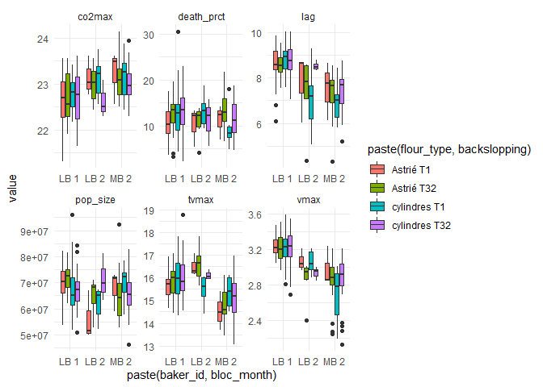

```r
ggplot(data_phenot_parms_clean_LBMB) +
  aes(x = paste(baker_id, bloc_month), y = value, fill = paste(flour_type, backslopping)) +
  geom_boxplot() +
  facet_wrap(~ parameter, scales = "free") +
  theme_minimal()
```

## 3.2 Formulation du modèle

The complete model is defined as follow :

```
phenotype ~ baker_id + backslopping + baker_id:backslopping + backslopping:flour_type + (1|strain_name) + (1|bloc_month)
```

## 3.3 Test des effets aléatoires

### 3.3.1 Model versions

```r
modv_LBMB_ran <- list(value ~ baker_id + backslopping + baker_id:backslopping
                      + backslopping:flour_type + (1|strain_name)
                    + (1|bloc_month),

                    value ~ baker_id + backslopping + baker_id:backslopping
                    + backslopping:flour_type + (1|strain_name),

                    value ~ baker_id + backslopping + baker_id:backslopping
                    + backslopping:flour_type + (1|bloc_month),

                    value ~ baker_id + backslopping + baker_id:backslopping
                    + backslopping:flour_type)
```

### 3.3.2 Model fitting

```r
fits <- data_phenot_parms_clean_LBMB %>%
  group_by(parameter) %>%
  nest() %>%
  mutate(n_model = length(modv_LBMB_ran)) %>%
  uncount(n_model) %>%
  ungroup() %>%
  mutate(model = rep(as.character(modv_LBMB_ran), length(unique(parameter))),
         id = 1:nrow(.),
         n_terms = str_count(" \\+ ", string = model) + 1) %>%
  rowwise() %>%

  #Uses 'lmer' if the model is mixed or 'lm' if the model is only made of fixed effects
  mutate(fit = ifelse(grepl("\\)$", model) == TRUE,
                      yes = list(lmer(as.formula(model), data, REML = F)),
                      no = list(lm(as.formula(model), data, contrasts = list(variable = "contr.sum"))))) %>%
  ungroup() %>%
  group_by(parameter) %>%

  # Indicates the id(s) of the model(s) in which the model of the given line is nested in
  mutate(nested_in = map2(model, id, ~ id[which(grepl(.x, model, fixed = T) & .y != id & abs(n_terms[match(.y, id)] - n_terms) == 1)])) %>%
  ungroup()
```

### 3.3.3 Likelihood Ratio Test (LRT)

Pour chaque paramètre (6), LRT entre chaque paire de modèle nichés (3) à 1 paramètre près.

```r
ran_test_LBMB <- fits %>%
  unnest(nested_in, keep_empty = T) %>%
  mutate(fit_long = fit[match(nested_in, id)],
         model_long = model[match(nested_in, id)]) %>%
  filter(!is.na(model_long)) %>%
  rowwise() %>%
  mutate(test = list(list(fit_long = model_long,
                          fit = model,
                          diff = as.character(sub(model, "", model_long, fixed = T)),
                          lrt = anova(fit_long, fit)))) %>%
  ungroup() %>%
  mutate(pval = map_dbl(test, ~ .$lrt$`Pr(>Chisq)`[2])) %>%
  filter(pval < 0.1)
```

Tests pour lesquels la *p.value* est inférieure à 0.1 :

```r
for(i in 1:nrow(ran_test_LBMB)) {

  cat("Parameter :", ran_test_LBMB$parameter[[i]], "\n")
  cat("Long :", ran_test_LBMB$model_long[[i]], "\n")
  cat("Short :", ran_test_LBMB$model[[i]], "\n")
  cat("Diff :", ran_test_LBMB$test[[i]]$diff, "\n\n")
  cat(grep("(npar)|(^fit   )|(^fit_long   )", capture.output(ran_test_LBMB$test[[i]]$lrt), value = TRUE), sep = "\n")
  cat("\n-----\n")

}
```

```
## Parameter : lag
## Long : value ~ baker_id + backslopping + baker_id:backslopping + backslopping:flour_type + (1 | strain_name) + (1 | bloc_month)
## Short : value ~ baker_id + backslopping + baker_id:backslopping + backslopping:flour_type + (1 | strain_name)
## Diff :  + (1 | bloc_month)
##
##          npar    AIC    BIC  logLik deviance  Chisq Df Pr(>Chisq)
## fit         8 579.86 606.97 -281.93   563.86
## fit_long    9 563.38 593.88 -272.69   545.38 18.481  1  1.716e-05 ***
##
## -----
## Parameter : lag
## Long : value ~ baker_id + backslopping + baker_id:backslopping + backslopping:flour_type + (1 | bloc_month)
## Short : value ~ baker_id + backslopping + baker_id:backslopping + backslopping:flour_type
## Diff :  + (1 | bloc_month)
##
##          npar    AIC    BIC  logLik deviance  Chisq Df Pr(>Chisq)
## fit         7 577.86 601.58 -281.93   563.86
## fit_long    8 561.38 588.49 -272.69   545.38 18.481  1  1.716e-05 ***
##
## -----
## Parameter : pop_size
## Long : value ~ baker_id + backslopping + baker_id:backslopping + backslopping:flour_type + (1 | strain_name)
## Short : value ~ baker_id + backslopping + baker_id:backslopping + backslopping:flour_type
## Diff :  + (1 | strain_name)
##
##          npar    AIC    BIC  logLik deviance  Chisq Df Pr(>Chisq)
## fit         7 7574.1 7597.8 -3780.0   7560.1
## fit_long    8 7572.4 7599.5 -3778.2   7556.4 3.6514  1    0.05602 .
##
## -----
## Parameter : vmax
## Long : value ~ baker_id + backslopping + baker_id:backslopping + backslopping:flour_type + (1 | strain_name) + (1 | bloc_month)
## Short : value ~ baker_id + backslopping + baker_id:backslopping + backslopping:flour_type + (1 | strain_name)
## Diff :  + (1 | bloc_month)
##
##          npar     AIC     BIC logLik deviance Chisq Df Pr(>Chisq)
## fit         8 -52.314 -25.202 34.157  -68.314
## fit_long    9 -64.445 -33.943 41.222  -82.445 14.13  1  0.0001706 ***
##
## -----
## Parameter : vmax
## Long : value ~ baker_id + backslopping + baker_id:backslopping + backslopping:flour_type + (1 | bloc_month)
## Short : value ~ baker_id + backslopping + baker_id:backslopping + backslopping:flour_type
## Diff :  + (1 | bloc_month)
##
##          npar     AIC     BIC logLik deviance Chisq Df Pr(>Chisq)
## fit         7 -54.314 -30.591 34.157  -68.314
## fit_long    8 -66.445 -39.332 41.222  -82.445 14.13  1  0.0001706 ***
##
## -----
```

Synthèse :

```r
ran_test_LBMB %>%
  mutate(diff = map_chr(test, ~ .$diff),
         pval = round(pval, 4)) %>%
  select(parameter, diff, pval)
```

```
## # A tibble: 5 x 3
##   parameter diff                     pval
##   <chr>     <chr>                   <dbl>
## 1 lag       " + (1 | bloc_month)"  0
## 2 lag       " + (1 | bloc_month)"  0
## 3 pop_size  " + (1 | strain_name)" 0.056
## 4 vmax      " + (1 | bloc_month)"  0.0002
## 5 vmax      " + (1 | bloc_month)"  0.0002
```

Comme dans le modèle avec uniquement `LB`, pour les variables $lag$, $V_{max}$, seul l’effet aléatoire $bloc_{month}$ doit être inclus au modèle. Pour les autres paramètres, aucun effet aléatoire n’est significatif.

## 3.4 Test des effets fixes

```
## value ~ baker_id + backslopping + baker_id:backslopping + backslopping:flour_type + (1 | bloc_month)
```

Et pour les variables $CO_2{max}$, $death_\%$ et $t_{V_{max}}$ le modèle complet est le suivant :

```
## value ~ baker_id + backslopping + baker_id:backslopping + backslopping:flour_type
```

### 3.4.1 Model fitting

```r
fits <- data_phenot_parms_clean_LBMB %>%
  group_by(parameter) %>%
  nest() %>%
  ungroup() %>%
  mutate(model = ifelse(parameter %in% c("lag", "vmax"),
                        list(mod_vers(value ~ backslopping + baker_id + baker_id:backslopping + backslopping:flour_type + (1 | bloc_month), 5)),
                        list(mod_vers(value ~ backslopping + baker_id + baker_id:backslopping + backslopping:flour_type)))) %>%
  unnest(model) %>%
  mutate(id = 1:nrow(.),
         n_terms = str_count(" \\+ ", string = model) + 1) %>%
  rowwise() %>%

  #Uses 'lmer' if the model is mixed (i.e. ending with a closing parenthese) or 'lm' if the model is only made of fixed effects
  mutate(fit = ifelse(grepl("\\)$", model) == TRUE,
                      yes = list(lmer(as.formula(model), data, REML = T)),
                      no = list(lm(as.formula(model), data)))) %>%
  ungroup()
```

### 3.4.2 Tableau d’ANOVA

```r
anovas <- fits %>%
  group_by(parameter) %>%
  filter(n_terms == max(n_terms)) %>%
  ungroup() %>%
  rowwise() %>%
  mutate(anova = list(anova(fit)))

for(i in 1:nrow(anovas)) {

  cat("Parameter :", anovas$parameter[[i]], "\n")
  cat("Model :", anovas$model[[i]], "\n")
  cat(capture.output(anovas$anova[[i]]), sep = "\n")
  cat("\n-----\n")

}
```

```
## Parameter : co2max
## Model : value ~ backslopping + baker_id + baker_id:backslopping + backslopping:flour_type
## Analysis of Variance Table
##
## Response: value
##                          Df Sum Sq Mean Sq F value    Pr(>F)
## backslopping              1  0.120  0.1202  0.5328    0.4662
## baker_id                  1  4.023  4.0233 17.8278 3.582e-05 ***
## backslopping:baker_id     1  0.084  0.0840  0.3722    0.5424
## backslopping:flour_type   2  0.442  0.2212  0.9803    0.3769
## Residuals               213 48.069  0.2257
## ---
## Signif. codes:  0 '***' 0.001 '**' 0.01 '*' 0.05 '.' 0.1 ' ' 1
##
## -----
## Parameter : death_prct
## Model : value ~ backslopping + baker_id + baker_id:backslopping + backslopping:flour_type
## Analysis of Variance Table
##
## Response: value
##                          Df Sum Sq Mean Sq F value Pr(>F)
## backslopping              1   44.8  44.796  2.3717 0.1250
## baker_id                  1   26.0  25.995  1.3763 0.2420
## backslopping:baker_id     1    7.5   7.534  0.3989 0.5283
## backslopping:flour_type   2   52.2  26.122  1.3830 0.2531
## Residuals               213 4023.1  18.888
##
## -----
## Parameter : lag
## Model : value ~ backslopping + baker_id + baker_id:backslopping + backslopping:flour_type + (1 | bloc_month)
## Type III Analysis of Variance Table with Satterthwaite's method
##                          Sum Sq Mean Sq NumDF  DenDF F value Pr(>F)
## backslopping            0.02125 0.02125     1 212.03  0.0305 0.8616
## baker_id                1.14690 1.14690     1 203.47  1.6436 0.2013
## backslopping:baker_id   0.40146 0.40146     1 212.00  0.5753 0.4490
## backslopping:flour_type 1.81795 0.90897     2 212.08  1.3026 0.2740
##
## -----
## Parameter : pop_size
## Model : value ~ backslopping + baker_id + baker_id:backslopping + backslopping:flour_type
```

[output cut: 25 more lines]

```
## Signif. codes:  0 '***' 0.001 '**' 0.01 '*' 0.05 '.' 0.1 ' ' 1
##
## -----
## Parameter : vmax
## Model : value ~ backslopping + baker_id + baker_id:backslopping + backslopping:flour_type + (1 | bloc_month)
## Type III Analysis of Variance Table with Satterthwaite's method
##                           Sum Sq  Mean Sq NumDF  DenDF F value   Pr(>F)
## backslopping            0.012406 0.012406     1 212.04  0.3120 0.577064
## baker_id                0.307960 0.307960     1 197.56  7.7440 0.005912 **
## backslopping:baker_id   0.083897 0.083897     1 212.00  2.1097 0.147846
## backslopping:flour_type 0.084712 0.042356     2 212.10  1.0651 0.346533
## ---
## Signif. codes:  0 '***' 0.001 '**' 0.01 '*' 0.05 '.' 0.1 ' ' 1
##
## -----
```

### 3.4.3 Figures

#### 3.4.3.1 Effets fixes

```r
sjPlot::tab_model(anovas$fit[[1]])
```

|  | value |  |  |
| --- | --- | --- | --- |
| Predictors | Estimates | CI | p |
| (Intercept) | 22.71 | 22.53 – 22.88 | **<0.001** |
| backslopping [T32] | 0.09 | -0.14 – 0.31 | 0.443 |
| baker id [MB] | 0.39 | 0.05 – 0.72 | **0.023** |
| backslopping [T32] * baker id [MB] | -0.11 | -0.47 – 0.26 | 0.573 |
| backslopping [T1] * flour typecylindres | 0.13 | -0.09 – 0.35 | 0.257 |
| backslopping [T32] * flour typecylindres | -0.07 | -0.22 – 0.09 | 0.414 |
| Observations | 219 |  |  |
| R<sup>2</sup> / R<sup>2</sup> adjusted | 0.089 / 0.067 |  |  |

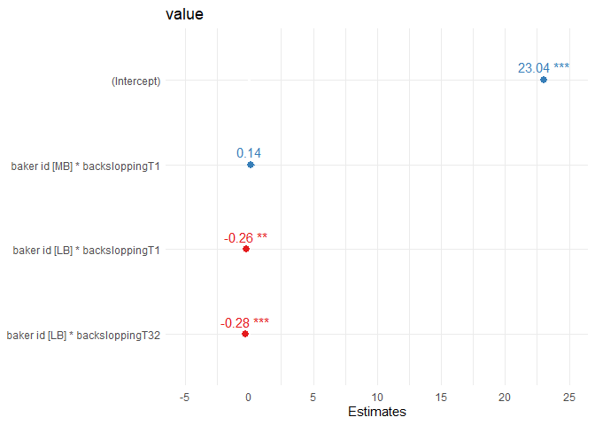

```r
sjPlot::plot_model(fits$fit[[3]], show.values = T, sort.est = T, show.intercept = T) + theme_minimal()
```

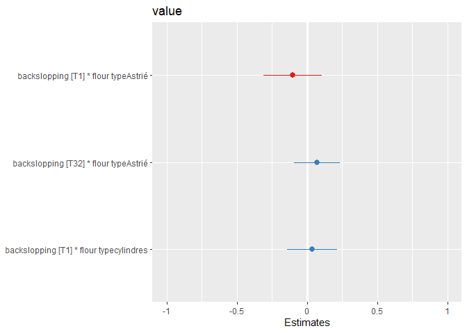

```r
sjPlot::plot_model(fits$fit[[4]])
```

```r
fits$fit[[3]] %>% anova()
```

```
## Analysis of Variance Table
##
## Response: value
##                        Df Sum Sq Mean Sq F value    Pr(>F)
## baker_id:backslopping   3  4.228 1.40918  6.2454 0.0004386 ***
## Residuals             215 48.511 0.22563
## ---
## Signif. codes:  0 '***' 0.001 '**' 0.01 '*' 0.05 '.' 0.1 ' ' 1
```

### 3.4.4 Comparaison des AICs

```r
fits %>%
  mutate(summary = map(fit, glance)) %>%
  unnest(summary) %>%
  select(-data, -fit) %>%
  group_by(parameter) %>%
  mutate(deltaAIC = AIC - min(AIC)) %>%
  select(id, parameter, model, logLik, AIC, deltaAIC, sigma, df.residual, n_terms) %>%
  mutate_if(is.numeric, ~ round(.x, 1)) %>%
  mutate(model = sub("^value ","", model),
         model = ifelse(deltaAIC < 2, str_replace_all(model, "^", "**"), model),
         model = ifelse(deltaAIC < 2, str_replace_all(model, "$", "**"), model)) %>%
  arrange(parameter, AIC, n_terms) %>%  kbl(format = "html", align = "c", escape = F) %>%
  kable_paper("striped", full_width = F) %>%
  row_spec(0, angle = 0) %>%
  scroll_box(width = "100%", height = "700px")
```

| id | parameter | model | logLik | AIC | deltaAIC | sigma | df.residual | n_terms |
| --- | --- | --- | --- | --- | --- | --- | --- | --- |
| 2 | co2max | **~ baker_id** | -146.1 | 298.2 | 0.0 | 0.5 | 217 | 1 |
| 5 | co2max | **~ backslopping + baker_id** | -145.9 | 299.8 | 1.6 | 0.5 | 216 | 2 |
| 3 | co2max | ~ baker_id:backslopping | -145.7 | 301.4 | 3.2 | 0.5 | 215 | 1 |
| 6 | co2max | ~ backslopping + baker_id:backslopping | -145.7 | 301.4 | 3.2 | 0.5 | 215 | 2 |
| 8 | co2max | ~ baker_id + baker_id:backslopping | -145.7 | 301.4 | 3.2 | 0.5 | 215 | 2 |
| 11 | co2max | ~ backslopping + baker_id + baker_id:backslopping | -145.7 | 301.4 | 3.2 | 0.5 | 215 | 3 |
| 9 | co2max | ~ baker_id + backslopping:flour_type | -144.9 | 301.7 | 3.5 | 0.5 | 214 | 2 |
| 12 | co2max | ~ backslopping + baker_id + backslopping:flour_type | -144.9 | 301.7 | 3.5 | 0.5 | 214 | 3 |
| 10 | co2max | ~ baker_id:backslopping + backslopping:flour_type | -144.7 | 303.4 | 5.2 | 0.5 | 213 | 2 |
| 13 | co2max | ~ backslopping + baker_id:backslopping + backslopping:flour_type | -144.7 | 303.4 | 5.2 | 0.5 | 213 | 3 |
| 14 | co2max | ~ baker_id + baker_id:backslopping + backslopping:flour_type | -144.7 | 303.4 | 5.2 | 0.5 | 213 | 3 |
| 15 | co2max | ~ backslopping + baker_id + baker_id:backslopping + backslopping:flour_type | -144.7 | 303.4 | 5.2 | 0.5 | 213 | 4 |
| 16 | co2max | ~ 1 | -154.8 | 313.7 | 15.5 | 0.5 | 218 | 1 |
| 1 | co2max | ~ backslopping | -154.6 | 315.2 | 17.0 | 0.5 | 217 | 1 |
| 4 | co2max | ~ backslopping:flour_type | -153.5 | 317.0 | 18.7 | 0.5 | 215 | 1 |
| 7 | co2max | ~ backslopping + backslopping:flour_type | -153.5 | 317.0 | 18.7 | 0.5 | 215 | 2 |
| 17 | death_prct | **~ backslopping** | -631.8 | 1269.6 | 0.0 | 4.4 | 217 | 1 |
| 32 | death_prct | **~ 1** | -633.0 | 1269.9 | 0.4 | 4.4 | 218 | 1 |
| 21 | death_prct | **~ backslopping + baker_id** | -631.1 | 1270.2 | 0.6 | 4.3 | 216 | 2 |
| 20 | death_prct | **~ backslopping:flour_type** | -630.5 | 1271.0 | 1.4 | 4.3 | 215 | 1 |
| 23 | death_prct | **~ backslopping + backslopping:flour_type** | -630.5 | 1271.0 | 1.4 | 4.3 | 215 | 2 |
| 25 | death_prct | **~ baker_id + backslopping:flour_type** | -629.7 | 1271.4 | 1.9 | 4.3 | 214 | 2 |
| 28 | death_prct | **~ backslopping + baker_id + backslopping:flour_type** | -629.7 | 1271.4 | 1.9 | 4.3 | 214 | 3 |
| 18 | death_prct | ~ baker_id | -632.8 | 1271.6 | 2.0 | 4.4 | 217 | 1 |
| 19 | death_prct | ~ baker_id:backslopping | -630.9 | 1271.8 | 2.2 | 4.4 | 215 | 1 |
| 22 | death_prct | ~ backslopping + baker_id:backslopping | -630.9 | 1271.8 | 2.2 | 4.4 | 215 | 2 |
| 24 | death_prct | ~ baker_id + baker_id:backslopping | -630.9 | 1271.8 | 2.2 | 4.4 | 215 | 2 |
| 27 | death_prct | ~ backslopping + baker_id + baker_id:backslopping | -630.9 | 1271.8 | 2.2 | 4.4 | 215 | 3 |
| 26 | death_prct | ~ baker_id:backslopping + backslopping:flour_type | -629.5 | 1272.9 | 3.4 | 4.3 | 213 | 2 |
| 29 | death_prct | ~ backslopping + baker_id:backslopping + backslopping:flour_type | -629.5 | 1272.9 | 3.4 | 4.3 | 213 | 3 |

[output cut: 66 more lines]

# 4 For ALL bakers

## 4.1 Data visualisation & Hypotheses

```r
table(strains$baker_id, strains$backslopping)
```

```
##
##       T1 T5 T32
##   AM   3 11   0
##   LB  20  3  24
##   MB   7  0  21
##   PDC  1  0   1
```

```r
data_phenot_parms_clean_ALL <- data_phenot_parms_clean %>%
  filter(parameter != "cell_t0") %>%
  mutate(flour_id = strains$flour_id[match(strain_name, strains$strain_name)],
         baker_id = strains$baker_id[match(strain_name, strains$strain_name)],
         flour_type = flours$mill_type[match(flour_id, flours$flour_id)],
         backslopping = strains$backslopping[match(strain_name,
                                                   strains$strain_name)],
         bs_time = backsloppings$bs_time[match(interaction(backslopping, baker_id),
                                               interaction(backsloppings$backslopping,
                                                           backsloppings$baker_id))],
         cell_t0 = data_cyto$cell_t0[match(robot_id, data_cyto$robot_id)]) %>%
  filter(!if_any(everything(), ~ is.na(.x)))
```

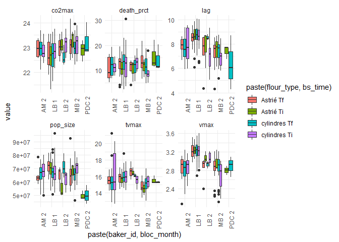

```r
ggplot(data_phenot_parms_clean_ALL) +
  aes(x = paste(baker_id, bloc_month), y = value, fill = paste(flour_type, bs_time)) +
  geom_boxplot() +
  facet_wrap(~ parameter, scales = "free") +
  theme_minimal() +
  theme(axis.text.x = element_text(angle = 90))
```

## 4.2 Formulation du modèle

The complete model is defined as follow :

```
phenotype ~ baker_id + bs_time + baker_id:bs_time + bs_time:flour_type + (1|strain_name) + (1|bloc_month)
```

## 4.3 Test des effets aléatoires

### 4.3.1 Model versions

```r
modv_ALL_ran <- list(value ~ baker_id + bs_time + baker_id:bs_time
                      + bs_time:flour_type + (1|strain_name)
                      + (1|bloc_month),

                      value ~ baker_id + bs_time + baker_id:bs_time
                      + bs_time:flour_type + (1|strain_name),

                      value ~ baker_id + bs_time + baker_id:bs_time
                      + bs_time:flour_type + (1|bloc_month),

                      value ~ baker_id + bs_time + baker_id:bs_time
                      + bs_time:flour_type)
```

### 4.3.2 Model fitting

```r
fits <- data_phenot_parms_clean_ALL %>%
  group_by(parameter) %>%
  nest() %>%
  mutate(n_model = length(modv_ALL_ran)) %>%
  uncount(n_model) %>%
  ungroup() %>%
  mutate(model = rep(as.character(modv_ALL_ran), length(unique(parameter))),
         id = 1:nrow(.),
         n_terms = str_count(" \\+ ", string = model) + 1) %>%
  rowwise() %>%

  #Uses 'lmer' if the model is mixed or 'lm' if the model is only made of fixed effects
  mutate(fit = ifelse(grepl("\\)$", model) == TRUE,
                      yes = list(lmer(as.formula(model), data, REML = F)),
                      no = list(lm(as.formula(model), data, contrasts = list(variable = "contr.sum"))))) %>%
  ungroup() %>%
  group_by(parameter) %>%

  # Indicates the id(s) of the model(s) in which the model of the given line is nested in
  mutate(nested_in = map2(model, id, ~ id[which(grepl(.x, model, fixed = T) & .y != id & abs(n_terms[match(.y, id)] - n_terms) == 1)])) %>%
  ungroup()
```

### 4.3.3 Likelihood Ratio Test (LRT)

Pour chaque paramètre (6), LRT entre chaque paire de modèle nichés (3) à 1 paramètre près.

```r
ran_test_ALL <- fits %>%
  unnest(nested_in, keep_empty = T) %>%
  mutate(fit_long = fit[match(nested_in, id)],
         model_long = model[match(nested_in, id)]) %>%
  filter(!is.na(model_long)) %>%
  rowwise() %>%
  mutate(test = list(list(fit_long = model_long,
                          fit = model,
                          diff = as.character(sub(model, "", model_long, fixed = T)),
                          lrt = anova(fit_long, fit)))) %>%
  ungroup() %>%
  mutate(pval = map_dbl(test, ~ .$lrt$`Pr(>Chisq)`[2])) %>%
  filter(pval < 0.1)
```

Tests pour lesquels la *p.value* est inférieure à 0.1 :

```r
for(i in 1:nrow(ran_test_ALL)) {

  cat("Parameter :", ran_test_ALL$parameter[[i]], "\n")
  cat("Long :", ran_test_ALL$model_long[[i]], "\n")
  cat("Short :", ran_test_ALL$model[[i]], "\n")
  cat("Diff :", ran_test_ALL$test[[i]]$diff, "\n\n")
  cat(grep("(npar)|(^fit   )|(^fit_long   )", capture.output(ran_test_ALL$test[[i]]$lrt), value = TRUE), sep = "\n")
  cat("\n-----\n")

}
```

```
## Parameter : lag
## Long : value ~ baker_id + bs_time + baker_id:bs_time + bs_time:flour_type + (1 | strain_name) + (1 | bloc_month)
## Short : value ~ baker_id + bs_time + baker_id:bs_time + bs_time:flour_type + (1 | strain_name)
## Diff :  + (1 | bloc_month)
##
##          npar    AIC    BIC  logLik deviance  Chisq Df Pr(>Chisq)
## fit        12 747.14 790.45 -361.57   723.14
## fit_long   13 734.19 781.12 -354.10   708.19 14.947  1  0.0001106 ***
##
## -----
## Parameter : lag
## Long : value ~ baker_id + bs_time + baker_id:bs_time + bs_time:flour_type + (1 | bloc_month)
## Short : value ~ baker_id + bs_time + baker_id:bs_time + bs_time:flour_type
## Diff :  + (1 | bloc_month)
##
##          npar    AIC    BIC  logLik deviance  Chisq Df Pr(>Chisq)
## fit        11 745.14 784.84 -361.57   723.14
## fit_long   12 732.19 775.51 -354.10   708.19 14.947  1  0.0001106 ***
##
## -----
## Parameter : pop_size
## Long : value ~ baker_id + bs_time + baker_id:bs_time + bs_time:flour_type + (1 | strain_name)
## Short : value ~ baker_id + bs_time + baker_id:bs_time + bs_time:flour_type
## Diff :  + (1 | strain_name)
##
##          npar    AIC    BIC  logLik deviance  Chisq Df Pr(>Chisq)
## fit        11 9437.2 9476.9 -4707.6   9415.2
## fit_long   12 9436.2 9479.5 -4706.1   9412.2 3.0013  1     0.0832 .
##
## -----
## Parameter : tvmax
## Long : value ~ baker_id + bs_time + baker_id:bs_time + bs_time:flour_type + (1 | strain_name)
## Short : value ~ baker_id + bs_time + baker_id:bs_time + bs_time:flour_type
## Diff :  + (1 | strain_name)
##
##          npar    AIC    BIC  logLik deviance  Chisq Df Pr(>Chisq)
## fit        11 790.20 829.90 -384.10   768.20
## fit_long   12 759.96 803.27 -367.98   735.96 32.239  1  1.363e-08 ***
##
## -----
## Parameter : vmax
## Long : value ~ baker_id + bs_time + baker_id:bs_time + bs_time:flour_type + (1 | strain_name) + (1 | bloc_month)
## Short : value ~ baker_id + bs_time + baker_id:bs_time + bs_time:flour_type + (1 | strain_name)
## Diff :  + (1 | bloc_month)
##
##          npar     AIC     BIC logLik deviance  Chisq Df Pr(>Chisq)
## fit        12 -40.112  3.2021 32.056  -64.112
## fit_long   13 -51.333 -4.4101 38.667  -77.333 13.222  1  0.0002767 ***
##
## -----
## Parameter : vmax
## Long : value ~ baker_id + bs_time + baker_id:bs_time + bs_time:flour_type + (1 | bloc_month)
## Short : value ~ baker_id + bs_time + baker_id:bs_time + bs_time:flour_type
## Diff :  + (1 | bloc_month)
##
##          npar     AIC     BIC logLik deviance  Chisq Df Pr(>Chisq)
## fit        11 -41.213 -1.5086 31.606  -63.213
## fit_long   12 -52.066 -8.7520 38.033  -76.066 12.853  1   0.000337 ***
##
## -----
```

Synthèse :

```r
ran_test_ALL %>%
  mutate(diff = map_chr(test, ~ .$diff),
         pval = round(pval, 4)) %>%
  select(parameter, diff, pval)
```

```
## # A tibble: 6 x 3
##   parameter diff                     pval
##   <chr>     <chr>                   <dbl>
## 1 lag       " + (1 | bloc_month)"  0.0001
## 2 lag       " + (1 | bloc_month)"  0.0001
## 3 pop_size  " + (1 | strain_name)" 0.0832
## 4 tvmax     " + (1 | strain_name)" 0
## 5 vmax      " + (1 | bloc_month)"  0.0003
## 6 vmax      " + (1 | bloc_month)"  0.0003
```

Donc pour les variables $lag$ et $V_{max}$, seul l’effet aléatoire $bloc_{month}$ doit être inclus au modèle. Pour la variable $t_{V_{max}}$, l’effet aléatoire $strain_{name}$ est ajouté. Pour les autres variables, aucun effet aléatoire n’est inclu.

## 4.4 Test des effets fixes

Donc, pour les variables $lag$, $V_{max}$. Le modèle complet ajusté est :

```
## value ~ baker_id + bs_time + baker_id:bs_time + bs_time:flour_type + (1 | bloc_month)
```

Pour la variables $t_{V_{max}}$, le modèle complet est le suivant :

```
## value ~ baker_id + bs_time + baker_id:bs_time + bs_time:flour_type + (1 | strain_name)
```

Et pour les variables $CO_2{max}$ et $death_\%$, le modèle complet est le suivant :

[output not shown]

### 4.4.1 Model fitting

```r
fits <- data_phenot_parms_clean_ALL %>%
  group_by(parameter) %>%
  nest() %>%
  ungroup() %>%
  mutate(model = case_when(parameter %in% c("lag", "vmax") ~ list(mod_vers(value ~ bs_time + baker_id + baker_id:bs_time + bs_time:flour_type + (1 | bloc_month), force = 5)),
                           parameter == "tvmax" ~ list(mod_vers(value ~ bs_time + baker_id + baker_id:bs_time + bs_time:flour_type + (1 | strain_name), force = 5)),
                           parameter %in% c("death_prct", "co2max","pop_size")  ~ list(mod_vers(value ~ bs_time + baker_id + baker_id:bs_time + flour_type + bs_time:flour_type)))) %>%
  unnest(model) %>%
  mutate(id = 1:nrow(.),
         n_terms = str_count(" \\+ ", string = model) + 1) %>%
  rowwise() %>%

  #Uses 'lmer' if the model is mixed (i.e. ending with a closing parenthese) or 'lm' if the model is only made of fixed effects
  mutate(fit = ifelse(grepl("\\)$", model) == TRUE,
                      yes = list(lmer(as.formula(model), data, REML = T)),
                      no = list(lm(as.formula(model), data)))) %>%
  ungroup()
```

### 4.4.2 Tableau d’ANOVA

```r
anovas <- fits %>%
  group_by(parameter) %>%
  filter(n_terms == max(n_terms)) %>%
  ungroup() %>%
  rowwise() %>%
  mutate(anova = list(anova(fit)))

for(i in 1:nrow(anovas)) {

  cat("Parameter :", anovas$parameter[[i]], "\n")
  cat("Model :", anovas$model[[i]], "\n")
  cat(capture.output(anovas$anova[[i]]), sep = "\n")
  cat("\n-----\n")

}
```

```
## Parameter : co2max
## Model : value ~ bs_time + baker_id + baker_id:bs_time + flour_type + bs_time:flour_type
## Analysis of Variance Table
##
## Response: value
##                     Df Sum Sq Mean Sq F value    Pr(>F)
## bs_time              1  0.160 0.15978  0.7317 0.3931266
## baker_id             3  4.224 1.40787  6.4469 0.0003157 ***
## flour_type           1  0.025 0.02519  0.1153 0.7344279
## bs_time:baker_id     3  0.399 0.13290  0.6086 0.6099690
## bs_time:flour_type   1  0.536 0.53617  2.4552 0.1183387
## Residuals          263 57.434 0.21838
## ---
## Signif. codes:  0 '***' 0.001 '**' 0.01 '*' 0.05 '.' 0.1 ' ' 1
##
## -----
## Parameter : death_prct
## Model : value ~ bs_time + baker_id + baker_id:bs_time + flour_type + bs_time:flour_type
## Analysis of Variance Table
##
## Response: value
##                     Df Sum Sq Mean Sq F value Pr(>F)
## bs_time              1   35.1  35.115  1.8503 0.1749
## baker_id             3   87.7  29.239  1.5407 0.2044
## flour_type           1   11.3  11.270  0.5939 0.4416
## bs_time:baker_id     3   23.3   7.781  0.4100 0.7460
## bs_time:flour_type   1   27.2  27.241  1.4354 0.2320
## Residuals          263 4991.2  18.978
##
## -----
## Parameter : lag
## Model : value ~ bs_time + baker_id + baker_id:bs_time + bs_time:flour_type + (1 | bloc_month)
## Type III Analysis of Variance Table with Satterthwaite's method
##                    Sum Sq Mean Sq NumDF  DenDF F value  Pr(>F)
## bs_time            1.6756 1.67562     1 262.03  2.1280 0.14583
## baker_id           5.9148 1.97161     3 258.06  2.5039 0.05968 .
## bs_time:baker_id   3.2173 1.07243     3 262.00  1.3620 0.25484
## bs_time:flour_type 1.2478 0.62389     2 262.08  0.7923 0.45387
## ---
## Signif. codes:  0 '***' 0.001 '**' 0.01 '*' 0.05 '.' 0.1 ' ' 1
```

[output cut: 27 more lines]

```
## Signif. codes:  0 '***' 0.001 '**' 0.01 '*' 0.05 '.' 0.1 ' ' 1
##
## -----
## Parameter : vmax
## Model : value ~ bs_time + baker_id + baker_id:bs_time + bs_time:flour_type + (1 | bloc_month)
## Type III Analysis of Variance Table with Satterthwaite's method
##                     Sum Sq  Mean Sq NumDF  DenDF F value  Pr(>F)
## bs_time            0.00485 0.004853     1 262.03  0.1089 0.74165
## baker_id           0.35338 0.117794     3 256.55  2.6435 0.04975 *
## bs_time:baker_id   0.13682 0.045606     3 262.00  1.0235 0.38270
## bs_time:flour_type 0.06334 0.031669     2 262.09  0.7107 0.49223
## ---
## Signif. codes:  0 '***' 0.001 '**' 0.01 '*' 0.05 '.' 0.1 ' ' 1
##
## -----
```

### 4.4.3 Comparaison des AICs

```r
fits %>%
  mutate(summary = map(fit, glance)) %>%
  unnest(summary) %>%
  select(-data, -fit) %>%
  group_by(parameter) %>%
  mutate(deltaAIC = AIC - min(AIC)) %>%
  select(id, parameter, model, logLik, AIC, deltaAIC, sigma, df.residual, n_terms) %>%
  mutate_if(is.numeric, ~ round(.x, 1)) %>%
  mutate(model = sub("^value ","", model),
         model = ifelse(deltaAIC < 2, str_replace_all(model, "^", "**"), model),
         model = ifelse(deltaAIC < 2, str_replace_all(model, "$", "**"), model)) %>%
  arrange(parameter, AIC, n_terms) %>%  kbl(format = "html", align = "c", escape = F) %>%
  kable_paper("striped", full_width = F) %>%
  row_spec(0, angle = 0) %>%
  scroll_box(width = "100%", height = "700px")
```

| id | parameter | model | logLik | AIC | deltaAIC | sigma | df.residual | n_terms |
| --- | --- | --- | --- | --- | --- | --- | --- | --- |
| 2 | co2max | **~ baker_id** | -177.0 | 364.0 | 0.0 | 0.5 | 269 | 1 |
| 6 | co2max | **~ bs_time + baker_id** | -176.9 | 365.7 | 1.7 | 0.5 | 268 | 2 |
| 11 | co2max | **~ baker_id + flour_type** | -176.9 | 365.9 | 1.9 | 0.5 | 268 | 2 |
| 12 | co2max | ~ baker_id + bs_time:flour_type | -175.6 | 367.3 | 3.2 | 0.5 | 266 | 2 |
| 18 | co2max | ~ bs_time + baker_id + bs_time:flour_type | -175.6 | 367.3 | 3.2 | 0.5 | 266 | 3 |
| 24 | co2max | ~ baker_id + flour_type + bs_time:flour_type | -175.6 | 367.3 | 3.2 | 0.5 | 266 | 3 |
| 28 | co2max | ~ bs_time + baker_id + flour_type + bs_time:flour_type | -175.6 | 367.3 | 3.2 | 0.5 | 266 | 4 |
| 17 | co2max | ~ bs_time + baker_id + flour_type | -176.8 | 367.6 | 3.5 | 0.5 | 267 | 3 |
| 3 | co2max | ~ baker_id:bs_time | -175.9 | 369.8 | 5.7 | 0.5 | 265 | 1 |
| 7 | co2max | ~ bs_time + baker_id:bs_time | -175.9 | 369.8 | 5.7 | 0.5 | 265 | 2 |
| 10 | co2max | ~ baker_id + baker_id:bs_time | -175.9 | 369.8 | 5.7 | 0.5 | 265 | 2 |
| 16 | co2max | ~ bs_time + baker_id + baker_id:bs_time | -175.9 | 369.8 | 5.7 | 0.5 | 265 | 3 |
| 14 | co2max | ~ baker_id:bs_time + bs_time:flour_type | -174.6 | 371.2 | 7.1 | 0.5 | 263 | 2 |
| 20 | co2max | ~ bs_time + baker_id:bs_time + bs_time:flour_type | -174.6 | 371.2 | 7.1 | 0.5 | 263 | 3 |
| 23 | co2max | ~ baker_id + baker_id:bs_time + bs_time:flour_type | -174.6 | 371.2 | 7.1 | 0.5 | 263 | 3 |
| 25 | co2max | ~ baker_id:bs_time + flour_type + bs_time:flour_type | -174.6 | 371.2 | 7.1 | 0.5 | 263 | 3 |
| 27 | co2max | ~ bs_time + baker_id + baker_id:bs_time + bs_time:flour_type | -174.6 | 371.2 | 7.1 | 0.5 | 263 | 4 |
| 29 | co2max | ~ bs_time + baker_id:bs_time + flour_type + bs_time:flour_type | -174.6 | 371.2 | 7.1 | 0.5 | 263 | 4 |
| 30 | co2max | ~ baker_id + baker_id:bs_time + flour_type + bs_time:flour_type | -174.6 | 371.2 | 7.1 | 0.5 | 263 | 4 |
| 31 | co2max | ~ bs_time + baker_id + baker_id:bs_time + flour_type + bs_time:flour_type | -174.6 | 371.2 | 7.1 | 0.5 | 263 | 5 |
| 13 | co2max | ~ baker_id:bs_time + flour_type | -175.9 | 371.7 | 7.7 | 0.5 | 264 | 2 |
| 19 | co2max | ~ bs_time + baker_id:bs_time + flour_type | -175.9 | 371.7 | 7.7 | 0.5 | 264 | 3 |
| 22 | co2max | ~ baker_id + baker_id:bs_time + flour_type | -175.9 | 371.7 | 7.7 | 0.5 | 264 | 3 |
| 26 | co2max | ~ bs_time + baker_id + baker_id:bs_time + flour_type | -175.9 | 371.7 | 7.7 | 0.5 | 264 | 4 |
| 32 | co2max | ~ 1 | -186.7 | 377.5 | 13.4 | 0.5 | 272 | 1 |
| 1 | co2max | ~ bs_time | -186.4 | 378.8 | 14.7 | 0.5 | 271 | 1 |
| 4 | co2max | ~ flour_type | -186.7 | 379.3 | 15.3 | 0.5 | 271 | 1 |
| 5 | co2max | ~ bs_time:flour_type | -185.3 | 380.6 | 16.6 | 0.5 | 269 | 1 |
| 8 | co2max | ~ bs_time + flour_type | -186.3 | 380.6 | 16.6 | 0.5 | 270 | 2 |
| 9 | co2max | ~ bs_time + bs_time:flour_type | -185.3 | 380.6 | 16.6 | 0.5 | 269 | 2 |

[output cut: 114 more lines]